# Nitrogen isotopes and land-use sources of coastal nitrate

## 1.2 Data quality report

```r
key_vars <- c(N15 = "N15", O18 = "O18", NOx = "NO3NO2", nitrite = "nitrite_umol", SiO2 = "SiO2",
              Salinity = "Salinity", rain = "chirps_storm_cumulative_mm",
              pct_ag = "pct_agriculture", cess_idx = "cess_exposure_idx",
              stream_dist = "dist_to_stream_mouth_m", slope = "mean_slope_deg", ksat = "mean_ksat_um_s",
              pct_imperv = "pct_impervious", npdes_dist = "dist_to_nearest_npdes_m",
              fetch = "fetch_mean_km", hs = "hs_mean_m")
dq_summary <- function(df, label) {
  df |>
    summarise(across(all_of(unname(key_vars)), list(
      n_missing = \(x) sum(is.na(x)), min = \(x) min(x, na.rm = TRUE),
      median = \(x) median(x, na.rm = TRUE), max = \(x) max(x, na.rm = TRUE)), .names = "{.col}__{.fn}")) |>
    pivot_longer(everything(), names_to = c("variable", ".value"), names_sep = "__") |>
    mutate(set = label, .before = 1)
}
bind_rows(dq_summary(water_all, "water_all"), dq_summary(water_iso, "water_iso")) |>
  mutate(across(c(min, median, max), \(x) signif(x, 3))) |>
  knitr::kable(caption = "Missingness and range of key variables (nitrite is NA where reported as <0.07).")
```

Missingness and range of key variables (nitrite is NA where reported as <0.07).

| set | variable | n_missing | min | median | max |
| --- | --- | --- | --- | --- | --- |
| water_all | N15 | 608 | 2.80e+00 | 8.40e+00 | 2.17e+01 |
| water_all | O18 | 730 | 4.00e-01 | 4.20e+00 | 1.01e+01 |
| water_all | NO3NO2 | 23 | 3.00e-02 | 1.08e+00 | 2.66e+02 |
| water_all | nitrite_umol | 17 | 0.00e+00 | 0.00e+00 | 9.72e+00 |
| water_all | SiO2 | 26 | 5.00e-03 | 8.38e+00 | 4.93e+02 |
| water_all | Salinity | 0 | 5.80e-01 | 3.36e+01 | 3.85e+01 |
| water_all | chirps_storm_cumulative_mm | 32 | 1.26e+02 | 2.50e+02 | 1.17e+03 |
| water_all | pct_agriculture | 11 | 0.00e+00 | 7.58e-03 | 6.79e-01 |
| water_all | cess_exposure_idx | 0 | 0.00e+00 | 1.89e+00 | 1.55e+02 |
| water_all | dist_to_stream_mouth_m | 0 | 5.76e-01 | 9.83e+02 | 1.14e+05 |
| water_all | mean_slope_deg | 11 | 4.37e-01 | 1.06e+01 | 2.46e+01 |
| water_all | mean_ksat_um_s | 19 | 2.20e-01 | 9.00e+00 | 1.52e+02 |
| water_all | pct_impervious | 11 | 7.53e-04 | 5.65e-02 | 6.14e-01 |
| water_all | dist_to_nearest_npdes_m | 0 | 3.35e-02 | 3.36e+02 | 9.42e+04 |
| water_all | fetch_mean_km | 0 | 7.33e-01 | 7.89e+01 | 2.78e+02 |
| water_all | hs_mean_m | 0 | 3.90e-01 | 1.02e+00 | 2.23e+00 |
| water_iso | N15 | 0 | 2.80e+00 | 8.40e+00 | 2.17e+01 |
| water_iso | O18 | 122 | 4.00e-01 | 4.20e+00 | 1.01e+01 |
| water_iso | NO3NO2 | 0 | 1.10e+00 | 4.58e+00 | 1.46e+02 |
| water_iso | nitrite_umol | 0 | 0.00e+00 | 0.00e+00 | 1.60e+00 |
| water_iso | SiO2 | 4 | 2.07e-01 | 1.66e+01 | 4.93e+02 |
| water_iso | Salinity | 0 | 1.50e+00 | 3.31e+01 | 3.82e+01 |
| water_iso | chirps_storm_cumulative_mm | 0 | 1.29e+02 | 2.48e+02 | 9.48e+02 |
| water_iso | pct_agriculture | 0 | 0.00e+00 | 1.64e-02 | 6.79e-01 |
| water_iso | cess_exposure_idx | 0 | 0.00e+00 | 1.97e+00 | 8.29e+01 |
| water_iso | dist_to_stream_mouth_m | 0 | 4.93e+00 | 9.67e+02 | 1.43e+04 |
| water_iso | mean_slope_deg | 0 | 5.33e-01 | 9.11e+00 | 2.46e+01 |
| water_iso | mean_ksat_um_s | 0 | 2.20e-01 | 1.01e+01 | 1.52e+02 |
| water_iso | pct_impervious | 0 | 2.03e-03 | 6.00e-02 | 6.14e-01 |
| water_iso | dist_to_nearest_npdes_m | 0 | 3.35e-02 | 2.68e+02 | 1.21e+04 |
| water_iso | fetch_mean_km | 0 | 4.63e+00 | 5.64e+01 | 1.57e+02 |
| water_iso | hs_mean_m | 0 | 3.90e-01 | 1.00e+00 | 1.90e+00 |

```r
tibble(
  check = c("Duplicate sample_id (water_all)", "Sites with >1 sample (water_all)",
            "Sites with >1 isotope sample", "Isotope samples sharing a site with another isotope sample"),
  n = c(sum(duplicated(water_all$sample_id)),
        sum(table(water_all$site_id) > 1),
        sum(table(water_iso$site_id) > 1),
        sum(duplicated(water_iso$site_id) | duplicated(water_iso$site_id, fromLast = TRUE)))
) |>
  knitr::kable(caption = "Duplicate and repeated-site checks.")
```

Duplicate and repeated-site checks.

| check | n |
| --- | --- |
| Duplicate sample_id (water_all) | 0 |
| Sites with >1 sample (water_all) | 33 |
| Sites with >1 isotope sample | 6 |
| Isotope samples sharing a site with another isotope sample | 12 |

```r
# Below-detection-limit values were set to DL/2 in chem_master, so BDL rows carry imputed values.
bind_rows(
  water_all |> summarise(set = "water_all", n = n(), bdl_NOx = sum(bdl_NO3NO2), bdl_SiO2 = sum(bdl_SiO2),
                         nitrite_below_0.07 = sum(nitrite_bdl, na.rm = TRUE)),
  water_iso |> summarise(set = "water_iso", n = n(), bdl_NOx = sum(bdl_NO3NO2), bdl_SiO2 = sum(bdl_SiO2),
                         nitrite_below_0.07 = sum(nitrite_bdl, na.rm = TRUE))
) |>
  knitr::kable(caption = "Below-detection-limit counts (flags from chem_master; nitrite DL = 0.07 umol/L).")
```

Below-detection-limit counts (flags from chem_master; nitrite DL = 0.07 umol/L).

| set | n | bdl_NOx | bdl_SiO2 | nitrite_below_0.07 |
| --- | --- | --- | --- | --- |
| water_all | 746 | 44 | 27 | 7 |
| water_iso | 138 | 0 | 0 | 0 |

```r
water_iso |> count(island) |> knitr::kable(caption = "Isotope samples by island.")
```

Isotope samples by island.

| island | n |
| --- | --- |
| O’ahu | 73 |
| Maui | 52 |
| Moloka’i | 12 |
| Lāna’i | 1 |

```r
water_iso |> count(island, ahupuaa, name = "n_iso") |> arrange(desc(n_iso)) |>
  slice_head(n = 15) |>
  knitr::kable(caption = paste0("Isotope samples by ahupua'a (top 15 of ", n_distinct(water_iso$ahupuaa_key), ")."))
```

Isotope samples by ahupua’a (top 15 of 56).

| island | ahupuaa | n_iso |
| --- | --- | --- |
| O’ahu | Waikīkī | 20 |
| Maui | Wailuku | 12 |
| Maui | Kamaʻole | 8 |
| O’ahu | Maunalua | 7 |
| O’ahu | Kawaihāpai | 6 |
| Maui | Hāmākuapoko | 5 |
| Moloka’i | Kaluako‘i | 5 |
| O’ahu | Kualoa 1 | 4 |
| Maui | Mohopilo | 4 |
| O’ahu | Honouliuli | 3 |
| O’ahu | Kahaluʻu | 3 |
| O’ahu | Kuliʻouʻou | 3 |
| O’ahu | Kāneʻohe | 3 |
| Maui | Kaʻonoʻulu | 3 |
| Maui | Kēōkea | 3 |

```r
water_iso |> mutate(date = as.Date(collected_hst)) |> count(date, name = "n_iso") |>
  left_join(water_all |> mutate(date = as.Date(collected_hst)) |> count(date, name = "n_all"), by = "date") |>
  mutate(pct_with_iso = round(100 * n_iso / n_all, 1)) |>
  knitr::kable(caption = "Isotope samples by sampling day (all samples for comparison).")
```

Isotope samples by sampling day (all samples for comparison).

| date | n_iso | n_all | pct_with_iso |
| --- | --- | --- | --- |
| 2026-03-28 | 16 | 112 | 14.3 |
| 2026-03-29 | 86 | 436 | 19.7 |
| 2026-03-30 | 31 | 152 | 20.4 |
| 2026-03-31 | 3 | 12 | 25.0 |
| 2026-04-01 | 1 | 4 | 25.0 |
| 2026-04-05 | 1 | 5 | 20.0 |

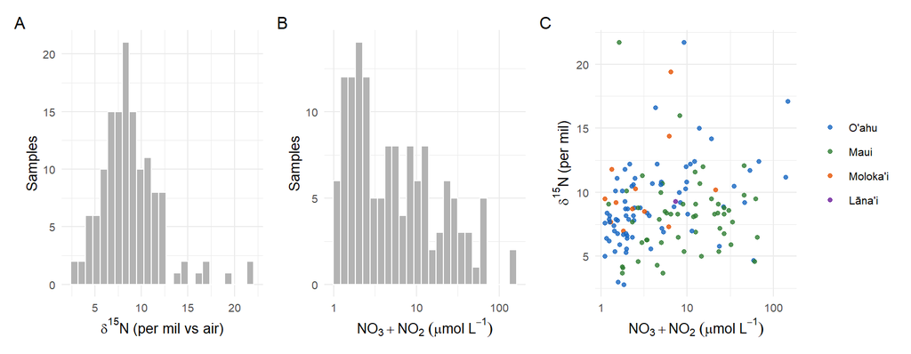

Figure 1

```r
p_n15 <- ggplot(water_iso, aes(N15)) + geom_histogram(bins = 25, fill = "gray70", color = "white") +
  labs(x = expression(delta^{15}*N~"(per mil vs air)"), y = "Samples", tag = "A") + theme_minimal(base_size = 10)
p_nox <- ggplot(water_iso, aes(NO3NO2)) + geom_histogram(bins = 25, fill = "gray70", color = "white") +
  scale_x_log10() + labs(x = expression(NO[3]+NO[2]~(mu*mol~L^{-1})), y = "Samples", tag = "B") + theme_minimal(base_size = 10)
p_iso_nox <- ggplot(water_iso, aes(NO3NO2, N15, color = island)) + geom_point(alpha = 0.8) +
  scale_x_log10() + scale_color_manual(values = island_pal, name = NULL) +
  labs(x = expression(NO[3]+NO[2]~(mu*mol~L^{-1})), y = expression(delta^{15}*N~"(per mil)"), tag = "C") +
  theme_minimal(base_size = 10)
p_n15 | p_nox | p_iso_nox
```

# 2 Representativeness of the isotope subset

The question is whether the 138 isotope samples can stand in for the full set of 746. Each variable is compared between isotope samples and the 608 samples without isotopes (an independent contrast; comparing against all 746 would put the isotope samples on both sides). The standardized mean difference (SMD) is the difference in means divided by the pooled SD; |SMD| < 0.1 is usually read as balanced and > 0.5 as a large imbalance. NOx, silica and cesspool exposure are compared on the same log scale used in the GAM.

```r
rep_vars <- tribble(
  ~var,                          ~label,                                            ~scale_note,
  "log_NO3NO2",                  "NO[3]+NO[2]~(log~mu*mol~L^{-1})",                 "log",
  "pct_agriculture",             "Agriculture~(fraction)",                          "raw",
  "log_cess_exposure",           "log(1+cesspool~exposure)",                        "log1p",
  "chirps_storm_cumulative_mm",  "Storm~rainfall~(mm)",                             "raw",
  "log_SiO2",                    "SiO[2]~(log~mu*mol~L^{-1})",                      "log",
  "Salinity",                    "Salinity~(PSU)",                                  "raw"
)
smd <- function(x, g) {
  a <- x[g]; b <- x[!g]
  (mean(a, na.rm = TRUE) - mean(b, na.rm = TRUE)) / sqrt((var(a, na.rm = TRUE) + var(b, na.rm = TRUE)) / 2)
}
# Smallest NOx among isotope samples; used below to describe the sampling range
nox_iso_min <- min(water_all$NO3NO2[water_all$has_iso])
rep_long <- water_all |>
  select(sample_id, island, has_iso, all_of(rep_vars$var)) |>
  pivot_longer(all_of(rep_vars$var), names_to = "var", values_to = "value") |>
  left_join(rep_vars, by = "var") |>
  mutate(label = factor(label, levels = rep_vars$label),
         group = if_else(has_iso, "Isotope subset", "No isotope"))
```

```r
smd_tab <- rep_vars |>
  rowwise() |>
  mutate(
    n_iso = sum(!is.na(water_all[[var]][water_all$has_iso])),
    n_other = sum(!is.na(water_all[[var]][!water_all$has_iso])),
    median_iso = median(water_all[[var]][water_all$has_iso], na.rm = TRUE),
    median_other = median(water_all[[var]][!water_all$has_iso], na.rm = TRUE),
    smd_all = smd(water_all[[var]], water_all$has_iso),
    smd_within_island = {
      d <- filter(water_all, island %in% c("O'ahu", "Maui"))
      # average of the two within-island SMDs (the only islands with enough isotope samples)
      mean(c(smd(d[[var]][d$island == "O'ahu"], d$has_iso[d$island == "O'ahu"]),
             smd(d[[var]][d$island == "Maui"], d$has_iso[d$island == "Maui"])))
    },
    smd_nox_ge_min = {
      d <- filter(water_all, NO3NO2 >= nox_iso_min)
      smd(d[[var]], d$has_iso)
    },
    ks_p = suppressWarnings(ks.test(water_all[[var]][water_all$has_iso], water_all[[var]][!water_all$has_iso])$p.value)
  ) |>
  ungroup() |>
  select(-label, -scale_note)
write_csv(smd_tab, here("output", "isotope", "tables", "isotope_representativeness_smd.csv"))
smd_tab |>
  knitr::kable(digits = 2, caption = paste0(
    "Isotope samples vs samples without isotopes. smd_within_island averages the O'ahu and Maui SMDs; ",
    "smd_nox_ge_min restricts both groups to NOx >= ", round(nox_iso_min, 2), " umol/L."))
```

Isotope samples vs samples without isotopes. smd_within_island averages the O’ahu and Maui SMDs; smd_nox_ge_min restricts both groups to NOx >= 1.1 umol/L.

| var | n_iso | n_other | median_iso | median_other | smd_all | smd_within_island | smd_nox_ge_min | ks_p |
| --- | --- | --- | --- | --- | --- | --- | --- | --- |
| log_NO3NO2 | 138 | 585 | 1.52 | -0.23 | 1.30 | 1.32 | 0.23 | 0.00 |
| pct_agriculture | 138 | 597 | 0.02 | 0.01 | 0.21 | 0.13 | -0.06 | 0.19 |
| log_cess_exposure | 138 | 608 | 1.09 | 1.05 | 0.07 | 0.04 | -0.14 | 0.04 |
| chirps_storm_cumulative_mm | 138 | 576 | 247.87 | 250.27 | -0.29 | -0.05 | -0.11 | 0.00 |
| log_SiO2 | 134 | 586 | 2.81 | 1.89 | 0.69 | 0.77 | 0.10 | 0.00 |
| Salinity | 138 | 608 | 33.09 | 33.68 | -0.10 | -0.13 | 0.10 | 0.03 |

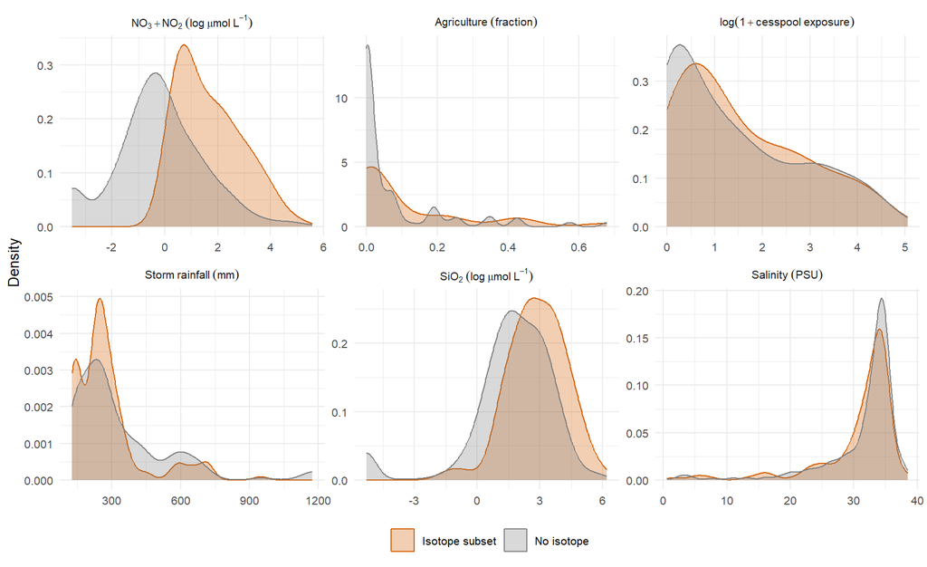

Figure 2

```r
ggplot(rep_long, aes(value, fill = group, color = group)) +
  geom_density(alpha = 0.3, adjust = 1.2, na.rm = TRUE) +
  facet_wrap(~label, scales = "free", labeller = label_parsed) +
  scale_fill_manual(values = c("Isotope subset" = "#D55E00", "No isotope" = "gray50"), name = NULL) +
  scale_color_manual(values = c("Isotope subset" = "#D55E00", "No isotope" = "gray50"), name = NULL) +
  labs(x = NULL, y = "Density") +
  theme_minimal(base_size = 10) + theme(legend.position = "bottom")
```

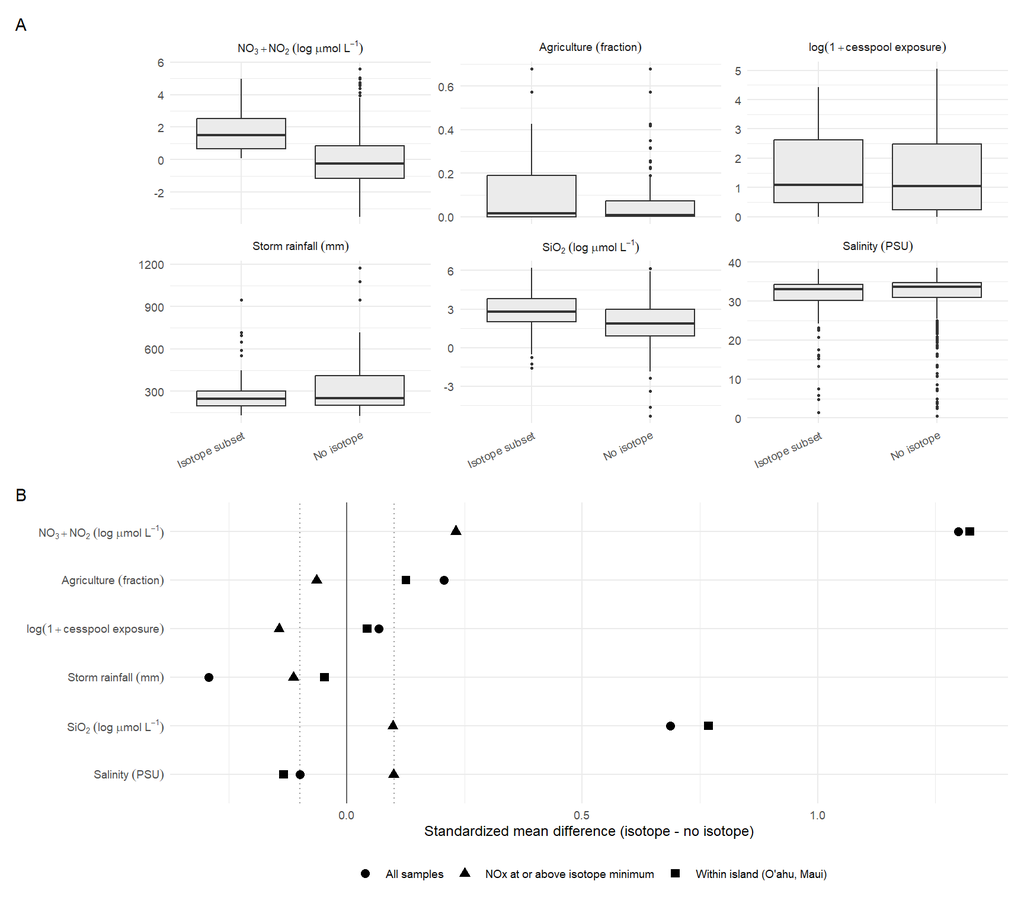

Figure 3

```r
p_box <- ggplot(rep_long, aes(group, value)) +
  geom_boxplot(outlier.size = 0.6, fill = "gray92") +
  facet_wrap(~label, scales = "free_y", labeller = label_parsed, nrow = 2) +
  labs(x = NULL, y = NULL, tag = "A") +
  theme_minimal(base_size = 9) + theme(axis.text.x = element_text(angle = 25, hjust = 1))
smd_long <- smd_tab |>
  select(var, `All samples` = smd_all, `Within island (O'ahu, Maui)` = smd_within_island,
         `NOx at or above isotope minimum` = smd_nox_ge_min) |>
  pivot_longer(-var, names_to = "comparison", values_to = "smd") |>
  left_join(select(rep_vars, var, label), by = "var") |>
  mutate(label = factor(label, levels = rev(rep_vars$label)))
p_smd <- ggplot(smd_long, aes(smd, label, shape = comparison)) +
  geom_vline(xintercept = c(-0.1, 0.1), linetype = "dotted", color = "gray60") +
  geom_vline(xintercept = 0, color = "gray40") +
  geom_point(size = 2.3) +
  scale_y_discrete(labels = \(x) parse(text = x)) +
  labs(x = "Standardized mean difference (isotope - no isotope)", y = NULL, shape = NULL, tag = "B") +
  theme_minimal(base_size = 9) + theme(legend.position = "bottom")
p_box / p_smd + plot_layout(heights = c(1.2, 1))
```